# MD05

Author

Wayne Frederick II

```r
library(tidyverse)
library(moderndive)
library(dplyr)
twitch_data <- read_csv("https://raw.githubusercontent.com/vaiseys/dav-course/main/Data/twitchdata-update.csv")
```

```r
library(janitor)
twitch_data <- clean_names(twitch_data)

# Inspect new names
colnames(twitch_data)
```

```
 [1] "channel"             "watch_time_minutes"  "stream_time_minutes"
 [4] "peak_viewers"        "average_viewers"     "followers"
 [7] "followers_gained"    "views_gained"        "partnered"
[10] "mature"              "language"
```

## Question 1

```r
evals_twitchdata <- twitch_data %>%
  select(average_viewers, followers)
glimpse(evals_twitchdata)
```

```
Rows: 1,000
Columns: 2
$ average_viewers <dbl> 27716, 25610, 10976, 7714, 29602, 42414, 24181, 18985,…
$ followers       <dbl> 3246298, 5310163, 1767635, 3944850, 8938903, 1563438, …
```

```r
evals_twitchdata <- twitch_data %>%
  select(average_viewers, followers)  %>%
   sample_n(size = 5)
view(evals_twitchdata)
```

Their average viewers is much less than the amount of followers they have.

```r
sum_twitchdata <- twitch_data %>%
  select(average_viewers, followers) %>%
  summary()
view(sum_twitchdata)
```

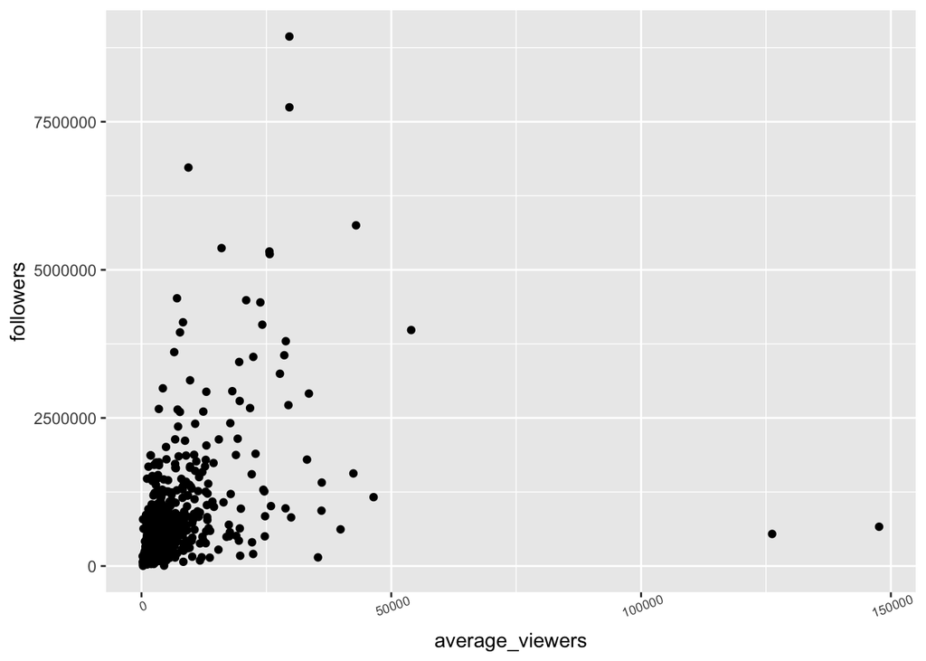

```r
ggplot(data = twitch_data, mapping = aes(x = average_viewers, y = followers)) +geom_point() + theme(axis.text.x = element_text(angle = 20, size =7))
```

```r
options(scipen=999)
```

The more followers tends to mean there will be a higher average viewership, but it is so concentrated that its difficult to tell.

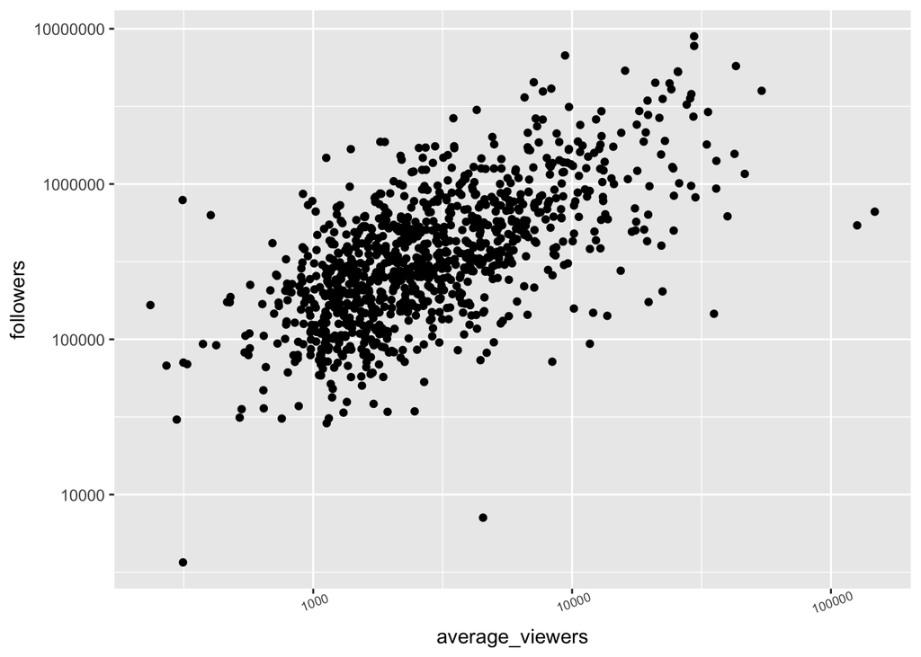

```r
ggplot(data = twitch_data, mapping = aes(x = average_viewers, y = followers)) +geom_point() + scale_x_log10() + scale_y_log10()+ theme(axis.text.x = element_text(angle = 20, size =7))
```

```r
options(scipen=999)
```

The data is much clearer now and obvious that followers and average viewers have a positive correlation.

```r
twitch_data <- twitch_data %>%
  mutate(log_viewers = log10(average_viewers),
         log_followers = log10(followers))
```

## Question 2

```r
twitchdata_model <- lm(log_viewers ~ log_followers, data = twitch_data)

get_regression_table(twitchdata_model)
```

```
# A tibble: 2 × 7
  term          estimate std_error statistic p_value lower_ci upper_ci
  <chr>            <dbl>     <dbl>     <dbl>   <dbl>    <dbl>    <dbl>
1 intercept        0.198     0.125      1.58   0.115   -0.048    0.444
2 log_followers    0.588     0.023     26.0    0        0.544    0.633
```

```r
library(broom)
fit1 <- twitchdata_model
tidy(fit1)
```

```
# A tibble: 2 × 5
  term          estimate std.error statistic   p.value
  <chr>            <dbl>     <dbl>     <dbl>     <dbl>
1 (Intercept)      0.198    0.125       1.58 1.15e-  1
2 log_followers    0.588    0.0226     26.0  1.69e-114
```

```r
1.1^{0.58}
```

```
[1] 1.056836
```

A 10% increase in followers is associated with a 5.6% increase in average number of viewers

## Question 3

```r
library(broom)

pred_data <- augment(fit1)


glimpse(pred_data)
```

```
Rows: 1,000
Columns: 8
$ log_viewers   <dbl> 4.442731, 4.408410, 4.040444, 3.887280, 4.471321, 4.6275…
$ log_followers <dbl> 6.511388, 6.725108, 6.247393, 6.596030, 6.951284, 6.1940…
$ .fitted       <dbl> 4.029761, 4.155534, 3.874400, 4.079572, 4.288638, 3.8430…
$ .resid        <dbl> 0.4129697, 0.2528757, 0.1660436, -0.1922928, 0.1826833, …
$ .hat          <dbl> 0.006194481, 0.008694557, 0.003782169, 0.007126066, 0.01…
$ .sigma        <dbl> 0.3085580, 0.3087321, 0.3087919, 0.3087764, 0.3087820, 0…
$ .cooksd       <dbl> 0.0056128779, 0.0029688873, 0.0005513456, 0.0014026033, …
$ .std.resid    <dbl> 1.3420109, 0.8227954, 0.5389316, -0.6251793, 0.5953620, …
```

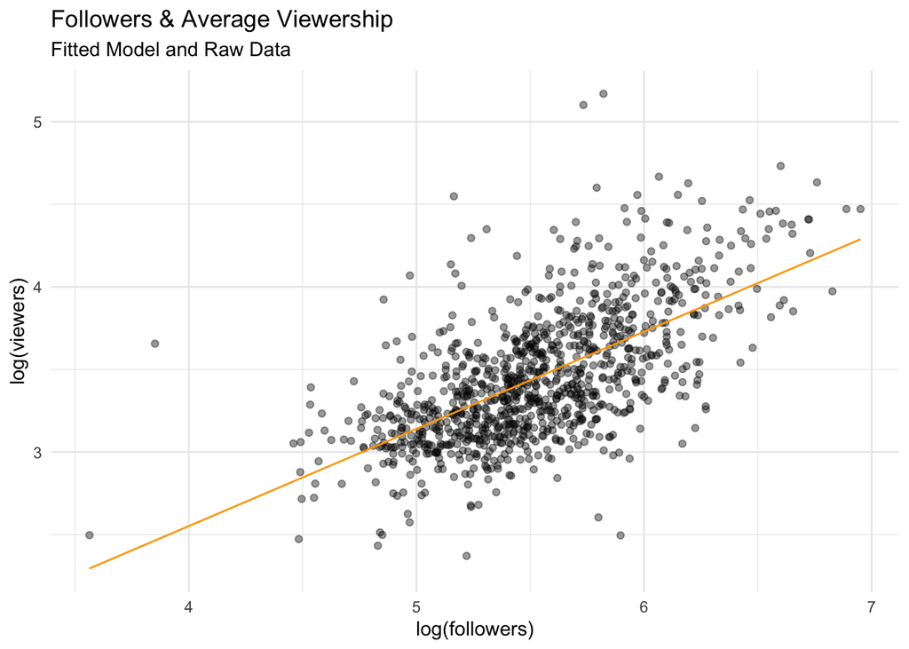

```r
pred_data %>%
  ggplot(aes(x = log_followers, y = log_viewers)) + geom_jitter(alpha = 0.4) +
  geom_line(aes(x = log_followers, y = .fitted), col = "orange") +
  theme_minimal() + labs(subtitle = "Fitted Model and Raw Data", title = "Followers & Average Viewership",  x = "log(followers)",  y = "log(viewers)")
```

I think this model describes it well because there is supposed to be a positive correlation.

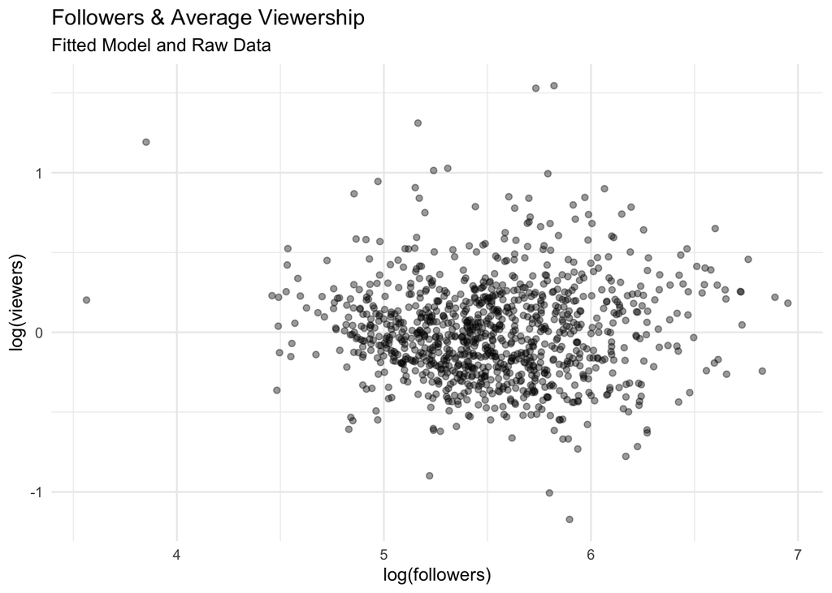

```r
pred_data %>%
  ggplot(aes(x = log_followers, y = .resid)) + geom_jitter(alpha = 0.4) +
  theme_minimal() + labs(subtitle = "Fitted Model and Raw Data", title = "Followers & Average Viewership",  x = "log(followers)",  y = "log(viewers)")
```

There are some residuals that are very big like over 1.5 and below -1, but other than that the residuals are pretty close. Residuals are the distance between each plotted points.

## Question 4

```r
langtwitchdata <- twitch_data %>%
  select(average_viewers, language)  %>%
   sample_n(size = 5)
view(langtwitchdata)
```

```r
sumtwitchdata <- twitch_data %>%
  select(average_viewers, language) %>%
  summary()
view(sumtwitchdata)
```

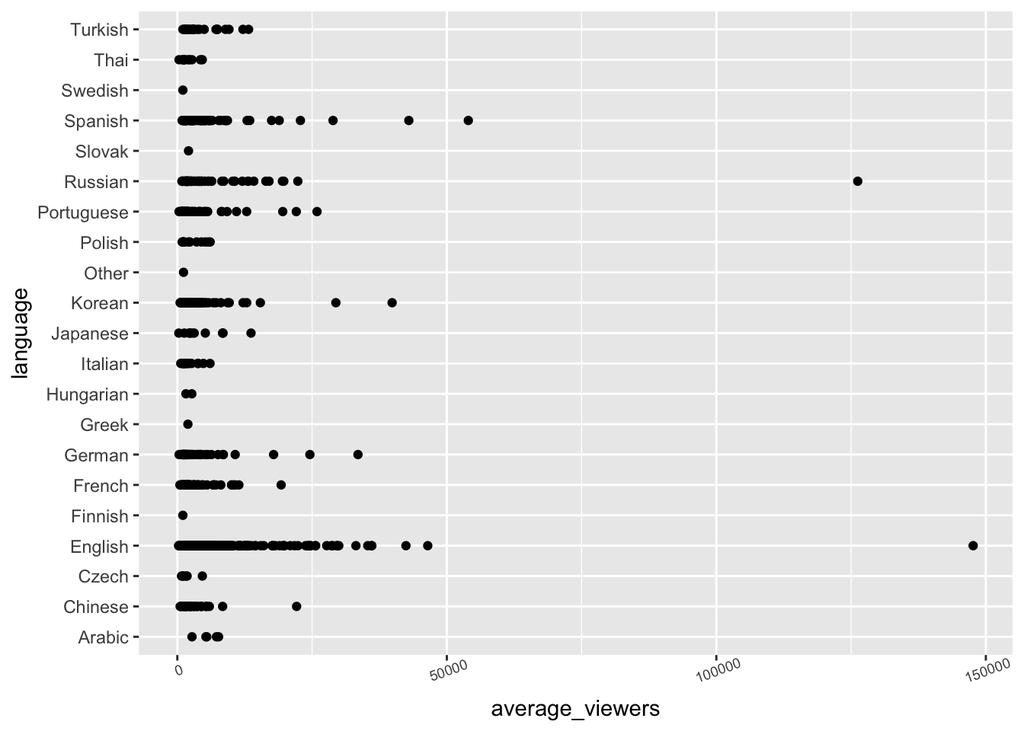

```r
ggplot(data = twitch_data, mapping = aes(x = average_viewers, y = language)) + geom_point() + theme(axis.text.x = element_text(angle = 20, size =7))
```

```r
options(scipen=999)
```

The two outliers here are DOTA2Ti in both English and Russian.

## Question 5

```r
twitch_data <- twitch_data %>%
  mutate(language = as.factor(language),
         language = relevel(language, ref = "English"))
```

```r
twitchdatamodel2 <- lm(average_viewers ~ language, data = twitch_data)

get_regression_table(twitchdatamodel2)
```

```
# A tibble: 21 × 7
   term                estimate std_error statistic p_value lower_ci upper_ci
   <chr>                  <dbl>     <dbl>     <dbl>   <dbl>    <dbl>    <dbl>
 1 intercept              5113.      385.    13.3     0        4358.    5868.
 2 language: Arabic        569.     3808.     0.15    0.881   -6903.    8042.
 3 language: Chinese     -1688.     1594.    -1.06    0.29    -4815.    1439.
 4 language: Czech       -3285.     3480.    -0.944   0.345  -10113.    3543.
 5 language: Finnish     -4086.     8480.    -0.482   0.63   -20726.   12555.
 6 language: French      -1606.     1111.    -1.44    0.149   -3787.     575.
 7 language: German       -835.     1270.    -0.657   0.511   -3326.    1657.
 8 language: Greek       -3152.     8480.    -0.372   0.71   -19792.   13489.
 9 language: Hungarian   -2972.     6002.    -0.495   0.621  -14751.    8806.
10 language: Italian     -2907.     2090.    -1.39    0.165   -7009.    1194.
# ℹ 11 more rows
```

```r
library(broom)
fit2 <- twitchdatamodel2
tidy(fit2)
```

```
# A tibble: 21 × 5
   term              estimate std.error statistic  p.value
   <chr>                <dbl>     <dbl>     <dbl>    <dbl>
 1 (Intercept)          5113.      385.    13.3   3.47e-37
 2 languageArabic        569.     3808.     0.150 8.81e- 1
 3 languageChinese     -1688.     1594.    -1.06  2.90e- 1
 4 languageCzech       -3285.     3480.    -0.944 3.45e- 1
 5 languageFinnish     -4086.     8480.    -0.482 6.30e- 1
 6 languageFrench      -1606.     1111.    -1.45  1.49e- 1
 7 languageGerman       -835.     1270.    -0.657 5.11e- 1
 8 languageGreek       -3152.     8480.    -0.372 7.10e- 1
 9 languageHungarian   -2972.     6002.    -0.495 6.21e- 1
10 languageItalian     -2907.     2090.    -1.39  1.65e- 1
# ℹ 11 more rows
```

There are 3 languages with higher average viewership than English and those are the ones with positive coefficients. The prediction is accurate for majority of languages.

## Question 6

```r
library(broom)

pred_data2 <- augment(fit2)


glimpse(pred_data2)
```

```
Rows: 1,000
Columns: 8
$ average_viewers <dbl> 27716, 25610, 10976, 7714, 29602, 42414, 24181, 18985,…
$ language        <fct> English, English, Portuguese, English, English, Englis…
$ .fitted         <dbl> 5112.814, 5112.814, 3800.934, 5112.814, 5112.814, 5112…
$ .resid          <dbl> 22603.186, 20497.186, 7175.066, 2601.186, 24489.186, 3…
$ .hat            <dbl> 0.002061856, 0.002061856, 0.016393443, 0.002061856, 0.…
$ .sigma          <dbl> 8444.313, 8449.818, 8472.094, 8474.843, 8438.923, 8390…
$ .cooksd         <dbl> 0.000701955520, 0.000577243111, 0.000578893083, 0.0000…
$ .std.resid      <dbl> 2.6710814, 2.4222095, 0.8540523, 0.3073893, 2.8939553,…
```

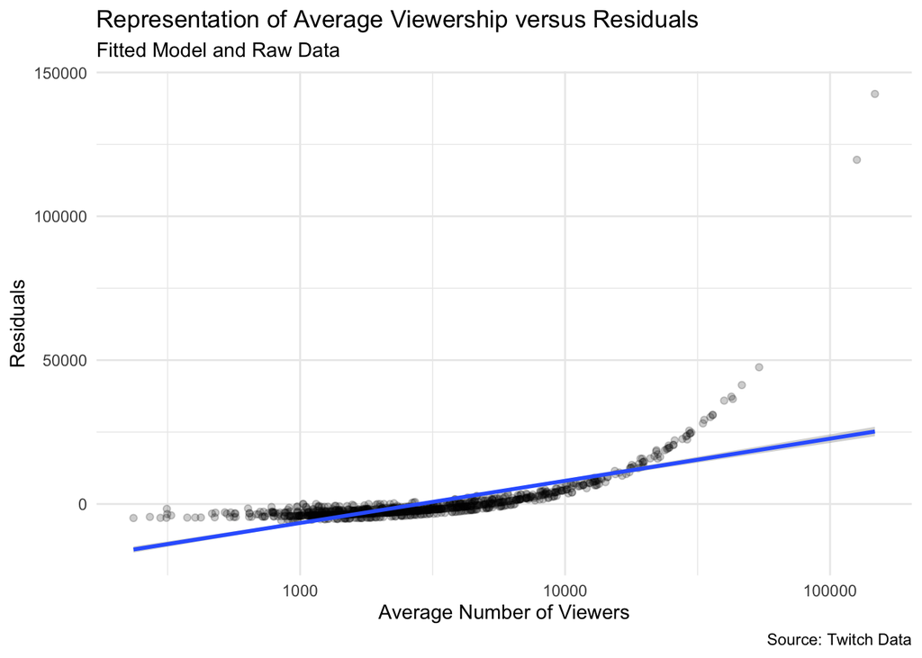

```r
pred_data2 %>% ggplot(aes(x = average_viewers, y = .resid)) + geom_jitter(alpha = 0.2) + geom_smooth(method = lm) + scale_x_log10() +theme_minimal() +
labs(subtitle = "Fitted Model and Raw Data", title = "Representation of Average Viewership versus Residuals", x = "Average Number of Viewers", y = "Residuals", caption = "Source: Twitch Data")
```

DOTA2Ti is the outlier here as well.